# ex_2

Haokang Chen

2024-11-18

# Enunciat

En un estudi per estudiar el nivell de colesterol en sang, en persones en edat de creixement (9-20 anys),s’ha plantejat un model per explicar el nivell de colesterol (C) en funció del pes (P ), edat (E) i alçada(H). És conegut que el pes és un dels factors que influeixen en l’augment del nivell de Colesterol, i es vol aprofundir en aquest fet. Les dades experimentals són independents i estan en el fitxer “col.csv”.

```r
library(car)
library(HH)
COL <- read.csv2("COL.csv", sep=";")
```

1. Per començar plategeu la recta de regressió del colesterol respecte el pes.
1. Trobeu l’estimació dels coeficients de la recta de regressió i de la variància del error, i interpreteu-los.

```r
head(COL)
```

```
##    A   H    W     C
## 1 19 174 79.9 189.5
## 2 15 151 64.5 197.5
## 3 13 133 52.0 170.5
## 4 19 173 75.5 180.5
## 5 17 163 74.0 216.5
## 6 13 135 54.9 173.5
```

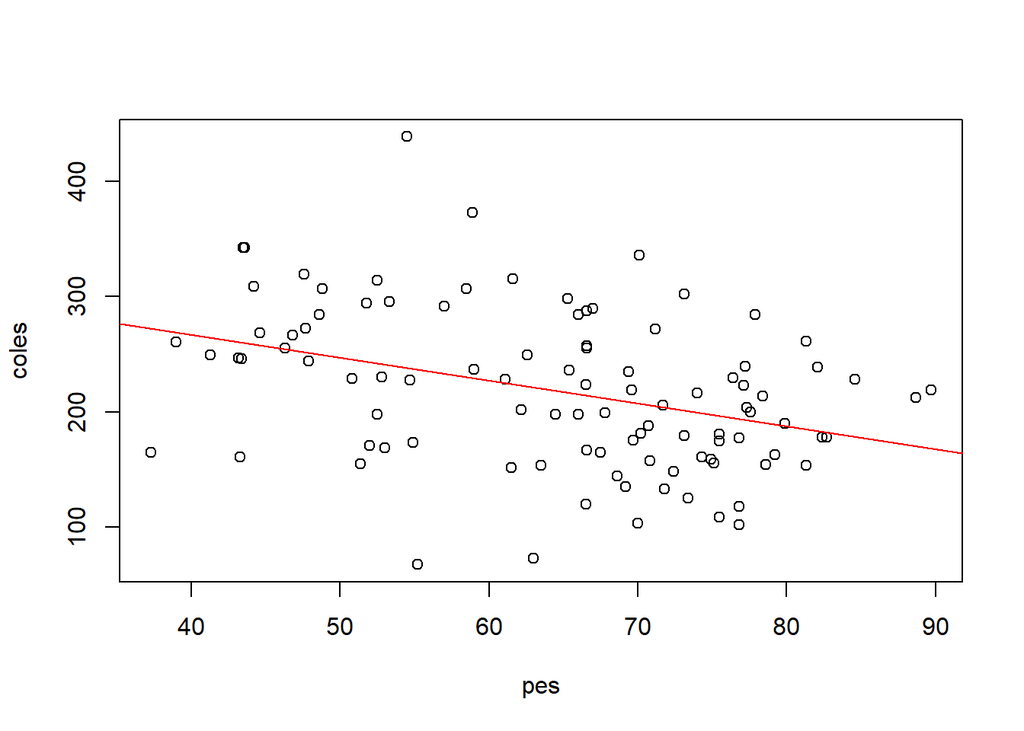

```r
pes <- COL$W
coles <- COL$C
plot(pes, coles)


model <- lm(C ~ W, data = COL)
abline(model, col = "red")
```

```r
summary(model)
```

```
##
## Call:
## lm(formula = C ~ W, data = COL)
##
## Residuals:
##     Min      1Q  Median      3Q     Max
## -169.24  -39.81   -4.49   47.19  200.37
##
## Coefficients:
##             Estimate Std. Error t value Pr(>|t|)
## (Intercept) 346.2251    33.1983   10.43  < 2e-16 ***
## W            -1.9835     0.5046   -3.93 0.000158 ***
## ---
## Signif. codes:  0 '***' 0.001 '**' 0.01 '*' 0.05 '.' 0.1 ' ' 1
##
## Residual standard error: 63.55 on 98 degrees of freedom
## Multiple R-squared:  0.1362, Adjusted R-squared:  0.1274
## F-statistic: 15.45 on 1 and 98 DF,  p-value: 0.0001581
```

2. Dieu si el pes explica, en part, la variabilitat en el nivell de colesterol. Veieu alguna contradicció en els resultats?

$R^2=.1362$, per tant la regressió és mala. A més, s’esperaria una relació positiva, però surt negativa.

3. Dibuixeu, juntament amb les dades la banda de confiança del 99 juntament amb la de predicció del nivell de colesterol en funció del pes.

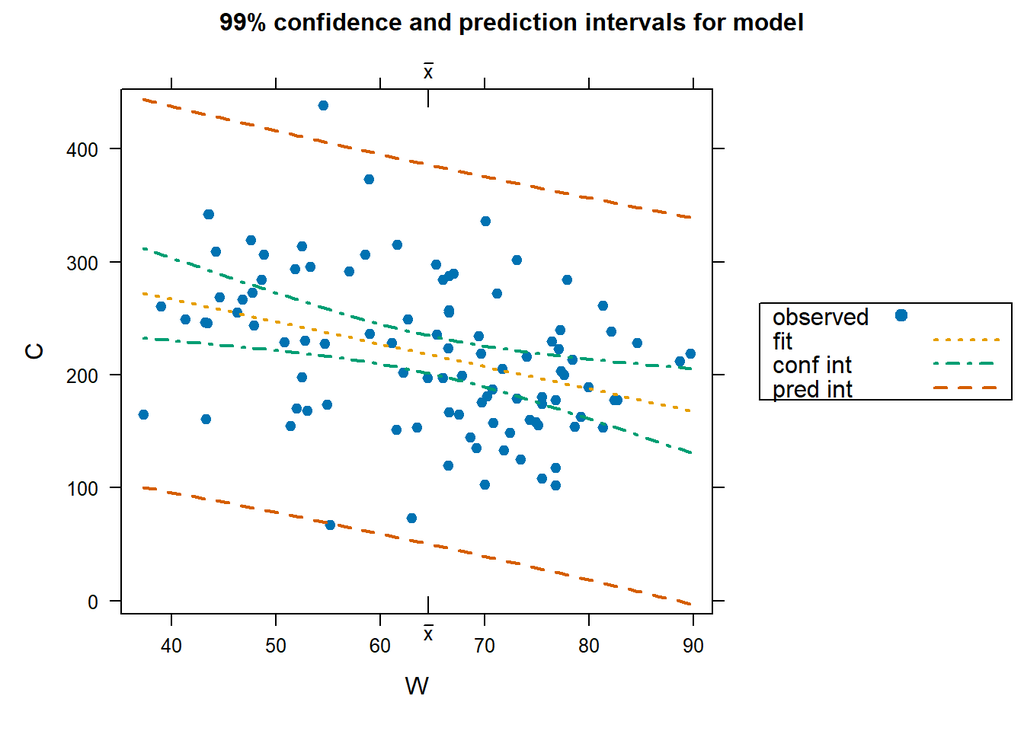

```r
ci.plot(model, conf.level = 0.99)
```

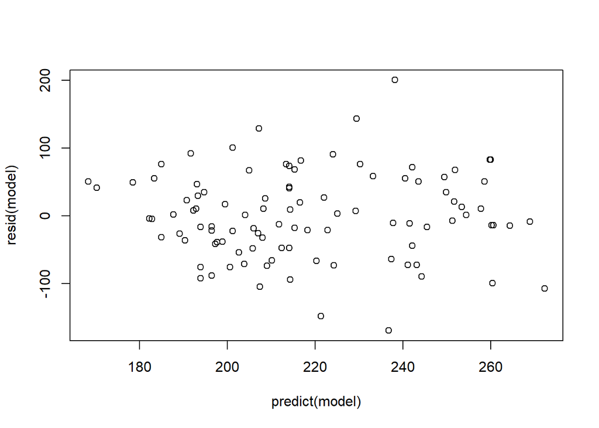

```r
plot(x = predict(model), y = resid(model))
```

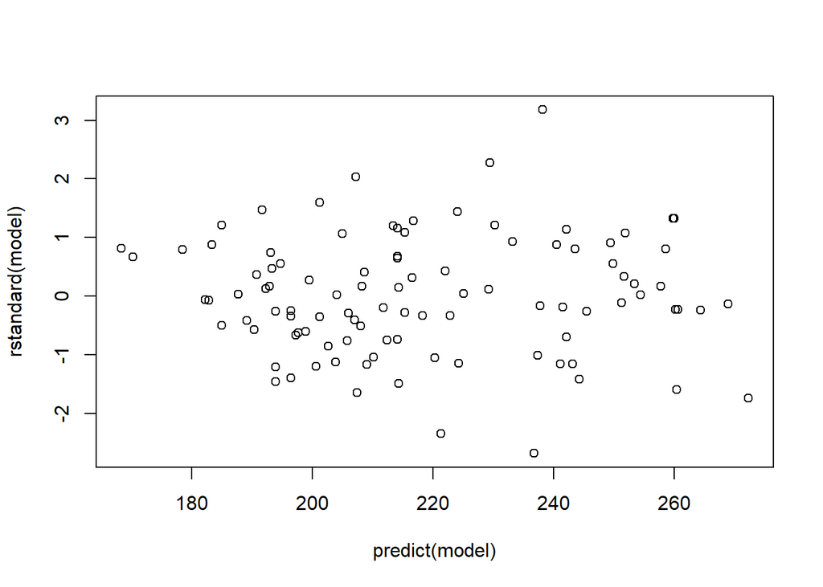

```r
plot(x = predict(model), y = rstandard(model))
```

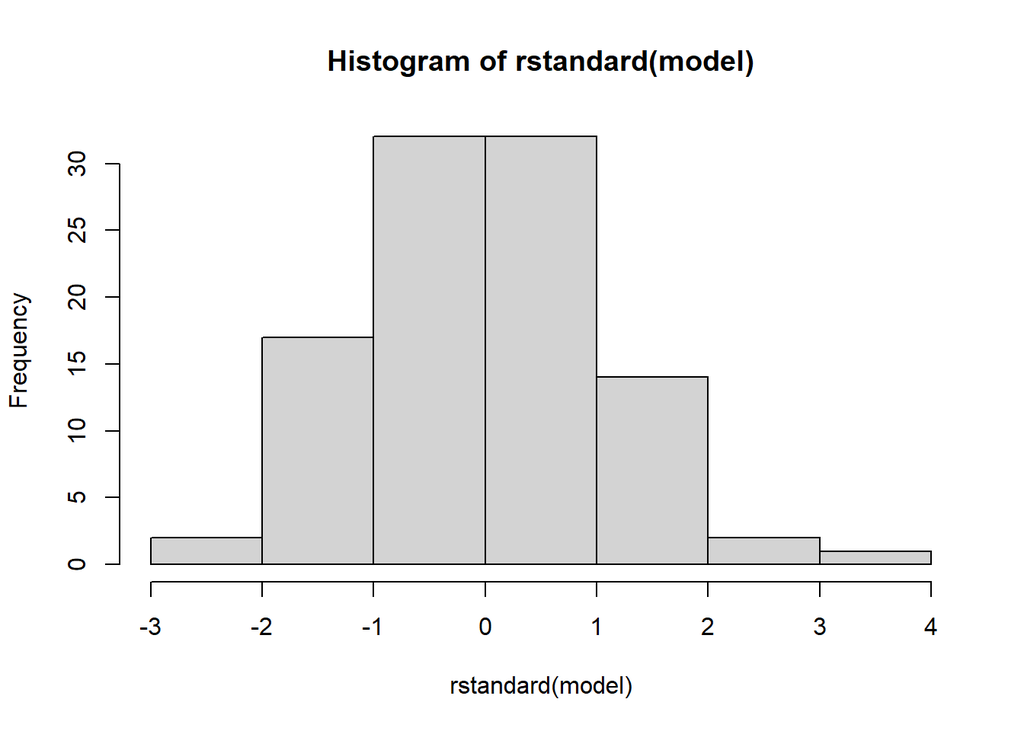

```r
hist(rstandard(model))
```

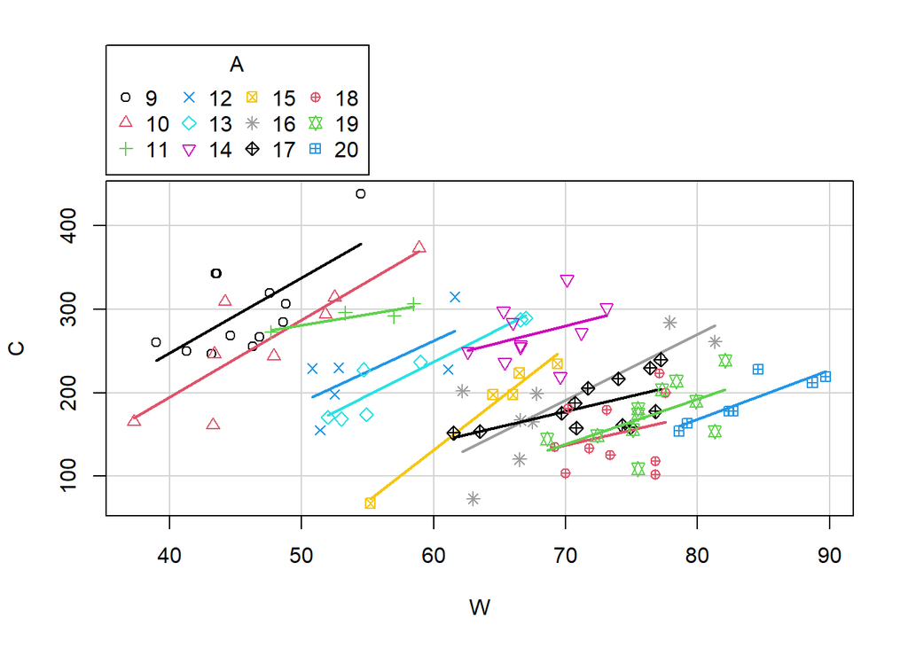

```r
scatterplot(C ~ W | A,
            smooth = F,
            col = 1:20,
            data = COL)
```